# Analysis of Life Expectancy by County

The results from the Oaxaca Blinder are examined in the twofold and threefold variations. The twofold decomposition accounts only for the explained differences based on differences in the explanatory vairables and unexplained differences not due to the explanatory variables.

The threefold decomposition also takes into account the interaction between the explained and unexplained differences.

```r
results$threefold$overall
```

```
  coef(endowments)     se(endowments) coef(coefficients)   se(coefficients)  coef(interaction)    se(interaction)
        0.74476648         0.03864031        -0.02934573         0.02050618         0.04386424         0.01689713
```

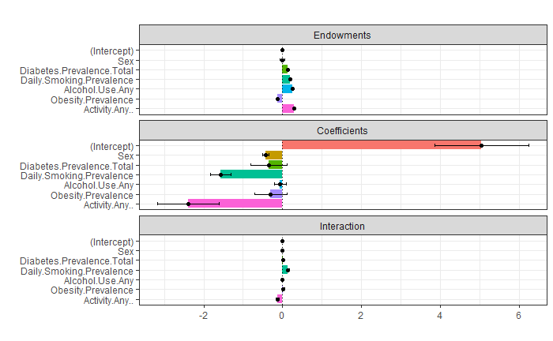

```r
plot(results, components = c("endowments","coefficients", "interaction"))
```

The Endowments from the threefold results shows the contribution of differences in the explanatory variables; the coefficients show the effect of them; the interaction accounts for the fact that cross-group differences in explanatory variables and coefficients occur at the same time.

```r
#two fold decomposition
 results$twofold$overall
```

```
     group.weight coef(explained) se(explained) coef(unexplained) se(unexplained) coef(unexplained A) se(unexplained A)
[1,]     0.000000       0.7447665    0.03821544       0.014518511      0.01682014        1.451851e-02      1.682014e-02
[2,]     1.000000       0.7886307    0.03707025      -0.029345725      0.01899357        0.000000e+00      0.000000e+00
[3,]     0.500000       0.7666986    0.03667262      -0.007413607      0.01579258        7.259256e-03      8.410069e-03
[4,]     0.271034       0.7566552    0.03661050       0.002629810      0.01680526        1.058350e-02      4.558830e-03
[5,]    -1.000000       0.7750048    0.03771845      -0.015719769      0.01252888       -1.145918e-02      9.124447e-03
[6,]    -2.000000       0.7781714    0.03783158      -0.018886396      0.01506636        1.668887e-12      5.061186e-12
     coef(unexplained B) se(unexplained B)
[1,]         0.000000000       0.000000000
[2,]        -0.029345725       0.018993571
[3,]        -0.014672863       0.009496785
[4,]        -0.007953690       0.013845667
[5,]        -0.004260593       0.003404801
[6,]        -0.018886396       0.015066356
```

The group weight of interest to us is -1, so the table is reconstructed without the irrelevant information and for each of the variables.

```r
variables <- c("Sex", "Diabetes.Prevalence.Total","Daily.Smoking.Prevalence","Alcohol.Use.Any","Obesity.Prevalence", "Activity.Any..")
columns <- c("group.weight","coef(explained)","coef(unexplained)", "coef(unexplained A)", "coef(unexplained B)")
results$twofold$variables[[5]][variables,columns]
```

```
                          group.weight coef(explained) coef(unexplained) coef(unexplained A) coef(unexplained B)
Sex                                 -1       0.0000000       -0.42071239         -0.34953516         -0.07117723
Diabetes.Prevalence.Total           -1       0.1384667       -0.33549638         -0.40879722          0.07330084
Daily.Smoking.Prevalence            -1       0.2206147       -1.46163582         -1.06888728         -0.39274855
Alcohol.Use.Any                     -1       0.2382002       -0.05818154          0.00284483         -0.06102637
Obesity.Prevalence                  -1      -0.1153225       -0.29054779         -0.10918561         -0.18136219
Activity.Any..                      -1       0.2930456       -2.50283193         -2.36921826         -0.13361367
```

The results are plotted below.

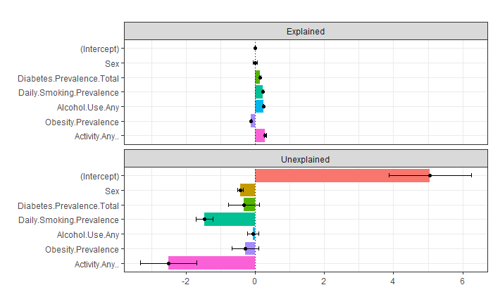

```r
 plot(results, decomposition = "twofold", group.weight = -1)
```

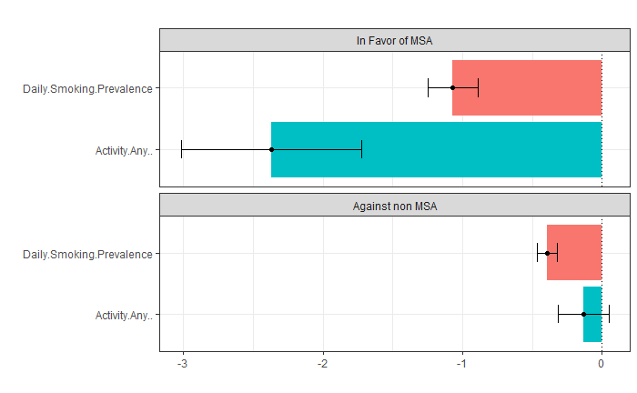

```r
 plot(results, decomposition = "twofold", group.weight = -1, unexplained.split=TRUE, components = c("unexplained A", "unexplained B"), component.labels = c("unexplained A" = "In Favor of MSA", "unexplained B" = "Against non MSA"), variables = c("Daily.Smoking.Prevalence","Activity.Any.."))
```

Finally, a fixed effects regression is run to isolate the effect of time. The Breusch-Pagan test and Hasuman test is first run to check if the fixed effects regression is an appropriate model.

```r
rm(list=ls())
require("plm")
require("lmtest")
mydata <- read.csv(file="C:/Users/mytan/Desktop/Archive/SBU Archive/Spring 2019/ECO487/Analysis of Life Expectancy by County/Data/Panel Data Analysis 1999-2007.csv", header=TRUE, sep=",")
MSAs <- mydata [which(mydata$MSA == 1),]
nonMSAs <- mydata[which(mydata$MSA==0),]
#testing to know if you want fixed effects
bptest(mydata$Male.life.expectancy..years ~mydata$MSA+mydata$Diabetes.PrevalenceTotal.Males+mydata$Smoking.Prevalence.Males.Daily.. + mydata$Alcohol.Use.Binge.. + mydata$Obesity.Prevalence.Males.. + mydata$Physical.Activity..Any..Prevalence.Males.., data = mydata, studentize = FALSE)
```

```
    Breusch-Pagan test

data:  mydata$Male.life.expectancy..years ~ mydata$MSA + mydata$Diabetes.PrevalenceTotal.Males +     mydata$Smoking.Prevalence.Males.Daily.. + mydata$Alcohol.Use.Binge.. +     mydata$Obesity.Prevalence.Males.. + mydata$Physical.Activity..Any..Prevalence.Males..
BP = 3508.5, df = 6, p-value < 2.2e-16
```

```r
phtest(mydata$Male.life.expectancy..years ~mydata$MSA+mydata$Diabetes.PrevalenceTotal.Males+mydata$Smoking.Prevalence.Males.Daily.. + mydata$Alcohol.Use.Binge.. + mydata$Obesity.Prevalence.Males.. + mydata$Physical.Activity..Sufficient..Prevalence.Females.., data = mydata)
```

```
    Hausman Test

data:  mydata$Male.life.expectancy..years ~ mydata$MSA + mydata$Diabetes.PrevalenceTotal.Males +  ...
chisq = 170.01, df = 6, p-value < 2.2e-16
alternative hypothesis: one model is inconsistent
```

```r
print("FIXED EFFECT")
```

```
[1] "FIXED EFFECT"
```

```r
#this regression is effects independent of time -- fixed effect
plmwithin <- plm(mydata$Male.life.expectancy..years ~mydata$MSA+mydata$Diabetes.PrevalenceTotal.Males+mydata$Smoking.Prevalence.Males.Daily.. + mydata$Alcohol.Use.Binge.. + mydata$Obesity.Prevalence.Males.. + mydata$Physical.Activity..Any..Prevalence.Males.. + mydata$MSA*mydata$Diabetes.PrevalenceTotal.Males+mydata$MSA*mydata$Smoking.Prevalence.Males.Daily.. +mydata$MSA* mydata$Alcohol.Use.Binge.. + mydata$MSA*mydata$Obesity.Prevalence.Males.. + mydata$MSA*mydata$Physical.Activity..Any..Prevalence.Males.., data = mydata, model = "within")
summary(plmwithin)
```

```
Oneway (individual) effect Within Model

Call:
plm(formula = mydata$Male.life.expectancy..years ~ mydata$MSA +
    mydata$Diabetes.PrevalenceTotal.Males + mydata$Smoking.Prevalence.Males.Daily.. +
    mydata$Alcohol.Use.Binge.. + mydata$Obesity.Prevalence.Males.. +
    mydata$Physical.Activity..Any..Prevalence.Males.. + mydata$MSA *
    mydata$Diabetes.PrevalenceTotal.Males + mydata$MSA * mydata$Smoking.Prevalence.Males.Daily.. +
    mydata$MSA * mydata$Alcohol.Use.Binge.. + mydata$MSA * mydata$Obesity.Prevalence.Males.. +
    mydata$MSA * mydata$Physical.Activity..Any..Prevalence.Males..,
    data = mydata, model = "within")

Unbalanced Panel: n = 9, T = 1957-2103, N = 18684

Residuals:
     Min.   1st Qu.    Median   3rd Qu.      Max.
-6.866140 -0.631979  0.056975  0.683737  5.633925

Coefficients:
                                                               Estimate Std. Error  t-value  Pr(>|t|)
mydata$MSA                                                    5.1710088  0.7211123   7.1709 7.730e-13 ***
mydata$Diabetes.PrevalenceTotal.Males                        -0.4310163  0.0081207 -53.0761 < 2.2e-16 ***
mydata$Smoking.Prevalence.Males.Daily..                      -0.1478458  0.0031853 -46.4151 < 2.2e-16 ***
mydata$Alcohol.Use.Binge..                                    0.0931948  0.0024783  37.6037 < 2.2e-16 ***
mydata$Obesity.Prevalence.Males..                             0.0587455  0.0041222  14.2511 < 2.2e-16 ***
mydata$Physical.Activity..Any..Prevalence.Males..             0.1134246  0.0029239  38.7918 < 2.2e-16 ***
mydata$MSA:mydata$Diabetes.PrevalenceTotal.Males             -0.0601060  0.0172073  -3.4931 0.0004786 ***
mydata$MSA:mydata$Smoking.Prevalence.Males.Daily..           -0.1096844  0.0061553 -17.8194 < 2.2e-16 ***
mydata$MSA:mydata$Alcohol.Use.Binge..                        -0.0397600  0.0053773  -7.3940 1.485e-13 ***
mydata$MSA:mydata$Obesity.Prevalence.Males..                  0.0311718  0.0073670   4.2313 2.335e-05 ***
mydata$MSA:mydata$Physical.Activity..Any..Prevalence.Males.. -0.0258215  0.0067820  -3.8074 0.0001409 ***
---
Signif. codes:  0 *** 0.001 ** 0.01 * 0.05 . 0.1   1

Total Sum of Squares:    87716
Residual Sum of Squares: 22834
R-Squared:      0.73968
Adj. R-Squared: 0.73942
F-statistic: 4821.19 on 11 and 18664 DF, p-value: < 2.22e-16
```

```r
plmwithin <- plm(mydata$Male.life.expectancy..years ~+mydata$Diabetes.PrevalenceTotal.Males+mydata$Smoking.Prevalence.Males.Daily.. + mydata$Alcohol.Use.Binge.. + mydata$Obesity.Prevalence.Males.. + mydata$Physical.Activity..Any..Prevalence.Males.. , data = mydata, model = "within")
summary(plmwithin)
```

```
Oneway (individual) effect Within Model

Call:
plm(formula = mydata$Male.life.expectancy..years ~ +mydata$Diabetes.PrevalenceTotal.Males +
    mydata$Smoking.Prevalence.Males.Daily.. + mydata$Alcohol.Use.Binge.. +
    mydata$Obesity.Prevalence.Males.. + mydata$Physical.Activity..Any..Prevalence.Males..,
    data = mydata, model = "within")

Unbalanced Panel: n = 9, T = 1957-2103, N = 18684

Residuals:
    Min.  1st Qu.   Median  3rd Qu.     Max.
-7.02724 -0.64131  0.05819  0.69475  6.17682

Coefficients:
                                                    Estimate Std. Error t-value  Pr(>|t|)
mydata$Diabetes.PrevalenceTotal.Males             -0.4363270  0.0071557 -60.976 < 2.2e-16 ***
mydata$Smoking.Prevalence.Males.Daily..           -0.1803949  0.0027198 -66.327 < 2.2e-16 ***
mydata$Alcohol.Use.Binge..                         0.0797869  0.0022025  36.226 < 2.2e-16 ***
mydata$Obesity.Prevalence.Males..                  0.0626560  0.0034324  18.254 < 2.2e-16 ***
mydata$Physical.Activity..Any..Prevalence.Males..  0.1129846  0.0026136  43.229 < 2.2e-16 ***
---
Signif. codes:  0 *** 0.001 ** 0.01 * 0.05 . 0.1   1

Total Sum of Squares:    87716
Residual Sum of Squares: 23359
R-Squared:      0.7337
Adj. R-Squared: 0.73351
F-statistic: 10287.6 on 5 and 18670 DF, p-value: < 2.22e-16
```

```r
print("FIXED EFFECT FEMALE")
```

```
[1] "FIXED EFFECT FEMALE"
```

```r
#this regression is effects independent of time -- fixed effect
plmwithinFemale <- plm(mydata$Female.life.expectancy..years ~mydata$MSA+mydata$Diabetes.PrevalenceTotal.Females+mydata$Smoking.Prevalence.Females.Daily.. + mydata$Alcohol.Use.Binge.. + mydata$Obesity.Prevalence.Females.. + mydata$Physical.Activity..Any..Prevalence.Females.. + mydata$MSA*mydata$Diabetes.PrevalenceTotal.Females+mydata$MSA*mydata$Smoking.Prevalence.Females.Daily.. +mydata$MSA* mydata$Alcohol.Use.Binge.. + mydata$MSA*mydata$Obesity.Prevalence.Females.. + mydata$MSA*mydata$Physical.Activity..Any..Prevalence.Females.., data = mydata, model = "within")
summary(plmwithinFemale)
```

```
Oneway (individual) effect Within Model

Call:
plm(formula = mydata$Female.life.expectancy..years ~ mydata$MSA +
    mydata$Diabetes.PrevalenceTotal.Females + mydata$Smoking.Prevalence.Females.Daily.. +
    mydata$Alcohol.Use.Binge.. + mydata$Obesity.Prevalence.Females.. +
    mydata$Physical.Activity..Any..Prevalence.Females.. + mydata$MSA *
    mydata$Diabetes.PrevalenceTotal.Females + mydata$MSA * mydata$Smoking.Prevalence.Females.Daily.. +
    mydata$MSA * mydata$Alcohol.Use.Binge.. + mydata$MSA * mydata$Obesity.Prevalence.Females.. +
    mydata$MSA * mydata$Physical.Activity..Any..Prevalence.Females..,
    data = mydata, model = "within")

Unbalanced Panel: n = 9, T = 1957-2103, N = 18684

Residuals:
     Min.   1st Qu.    Median   3rd Qu.      Max.
-4.541317 -0.508016 -0.005921  0.487732  5.521383

Coefficients:
                                                                 Estimate Std. Error  t-value  Pr(>|t|)
mydata$MSA                                                      4.6692732  0.4779954   9.7684 < 2.2e-16 ***
mydata$Diabetes.PrevalenceTotal.Females                        -0.1398687  0.0066200 -21.1281 < 2.2e-16 ***
mydata$Smoking.Prevalence.Females.Daily..                      -0.0305907  0.0022193 -13.7840 < 2.2e-16 ***
mydata$Alcohol.Use.Binge..                                      0.0804310  0.0019066  42.1859 < 2.2e-16 ***
mydata$Obesity.Prevalence.Females..                            -0.0207478  0.0030995  -6.6939 2.234e-11 ***
mydata$Physical.Activity..Any..Prevalence.Females..             0.0957485  0.0022887  41.8357 < 2.2e-16 ***
mydata$MSA:mydata$Diabetes.PrevalenceTotal.Females             -0.0286386  0.0140874  -2.0329   0.04207 *
mydata$MSA:mydata$Smoking.Prevalence.Females.Daily..           -0.0767130  0.0043681 -17.5621 < 2.2e-16 ***
mydata$MSA:mydata$Alcohol.Use.Binge..                          -0.0187164  0.0040877  -4.5788 4.708e-06 ***
mydata$MSA:mydata$Obesity.Prevalence.Females..                 -0.0215659  0.0055241  -3.9040 9.496e-05 ***
mydata$MSA:mydata$Physical.Activity..Any..Prevalence.Females.. -0.0259980  0.0047540  -5.4686 4.593e-08 ***
---
Signif. codes:  0 *** 0.001 ** 0.01 * 0.05 . 0.1   1

Total Sum of Squares:    45370
Residual Sum of Squares: 12785
R-Squared:      0.71821
Adj. R-Squared: 0.71793
F-statistic: 4324.59 on 11 and 18664 DF, p-value: < 2.22e-16
```

```r
plmwithin <- plm(mydata$Female.life.expectancy..years ~+mydata$Diabetes.PrevalenceTotal.Females+mydata$Smoking.Prevalence.Females.Daily.. + mydata$Alcohol.Use.Binge.. + mydata$Obesity.Prevalence.Females.. + mydata$Physical.Activity..Any..Prevalence.Females.. , data = mydata, model = "within")
summary(plmwithin)
```

```
Oneway (individual) effect Within Model

Call:
plm(formula = mydata$Female.life.expectancy..years ~ +mydata$Diabetes.PrevalenceTotal.Females +
    mydata$Smoking.Prevalence.Females.Daily.. + mydata$Alcohol.Use.Binge.. +
    mydata$Obesity.Prevalence.Females.. + mydata$Physical.Activity..Any..Prevalence.Females..,
    data = mydata, model = "within")

Unbalanced Panel: n = 9, T = 1957-2103, N = 18684

Residuals:
     Min.   1st Qu.    Median   3rd Qu.      Max.
-4.275401 -0.513847 -0.004608  0.487614  5.907147

Coefficients:
                                                      Estimate Std. Error t-value  Pr(>|t|)
mydata$Diabetes.PrevalenceTotal.Females             -0.1300056  0.0057955 -22.432 < 2.2e-16 ***
mydata$Smoking.Prevalence.Females.Daily..           -0.0537058  0.0019062 -28.174 < 2.2e-16 ***
mydata$Alcohol.Use.Binge..                           0.0739886  0.0016928  43.709 < 2.2e-16 ***
mydata$Obesity.Prevalence.Females..                 -0.0356448  0.0025502 -13.977 < 2.2e-16 ***
mydata$Physical.Activity..Any..Prevalence.Females..  0.0901120  0.0020128  44.770 < 2.2e-16 ***
---
Signif. codes:  0 *** 0.001 ** 0.01 * 0.05 . 0.1   1

Total Sum of Squares:    45370
Residual Sum of Squares: 13078
R-Squared:      0.71175
Adj. R-Squared: 0.71155
F-statistic: 9219.94 on 5 and 18670 DF, p-value: < 2.22e-16
```

The results from the fixed effects regression shows similar relationships between the explanatory variables and life expectancy as the results from the pooled ordinary least squares regression.

The fixed effects regression is then done in only MSAs and only nonMSAs to view the trend of life expectancy over time for MSAs, nonMSAs, and both MSAs and nonMSAs.

```r
#MSA
print("FIXED EFFECT MSA")
```

```
[1] "FIXED EFFECT MSA"
```

```r
#this regression is effects independent of time -- fixed effect
plmwithinMSA <- plm(MSAs$Male.life.expectancy..years ~MSAs$MSA+MSAs$Diabetes.PrevalenceTotal.Males+MSAs$Smoking.Prevalence.Males.Daily.. + MSAs$Alcohol.Use.Binge.. + MSAs$Obesity.Prevalence.Males.. + MSAs$Physical.Activity..Any..Prevalence.Males.., data=MSAs, model = "within")
summary(plmwithinMSA)
```

```
Oneway (individual) effect Within Model

Call:
plm(formula = MSAs$Male.life.expectancy..years ~ MSAs$MSA + MSAs$Diabetes.PrevalenceTotal.Males +
    MSAs$Smoking.Prevalence.Males.Daily.. + MSAs$Alcohol.Use.Binge.. +
    MSAs$Obesity.Prevalence.Males.. + MSAs$Physical.Activity..Any..Prevalence.Males..,
    data = MSAs, model = "within")

Unbalanced Panel: n = 9, T = 546-570, N = 5064

Residuals:
     Min.   1st Qu.    Median   3rd Qu.      Max.
-6.679878 -0.647204  0.073805  0.713944  4.780634

Coefficients:
                                                  Estimate Std. Error t-value  Pr(>|t|)
MSAs$Diabetes.PrevalenceTotal.Males             -0.4799871  0.0165393 -29.021 < 2.2e-16 ***
MSAs$Smoking.Prevalence.Males.Daily..           -0.2764070  0.0060528 -45.666 < 2.2e-16 ***
MSAs$Alcohol.Use.Binge..                         0.0571596  0.0052490  10.890 < 2.2e-16 ***
MSAs$Obesity.Prevalence.Males..                  0.0876269  0.0066020  13.273 < 2.2e-16 ***
MSAs$Physical.Activity..Any..Prevalence.Males..  0.0818921  0.0068799  11.903 < 2.2e-16 ***
---
Signif. codes:  0 *** 0.001 ** 0.01 * 0.05 . 0.1   1

Total Sum of Squares:    22339
Residual Sum of Squares: 7056.4
R-Squared:      0.68412
Adj. R-Squared: 0.68331
F-statistic: 2187.44 on 5 and 5050 DF, p-value: < 2.22e-16
```

```r
print("FIXED EFFECT MSA FEMALE")
```

```
[1] "FIXED EFFECT MSA FEMALE"
```

```r
#this regression is effects independent of time -- fixed effect
plmwithinMSAFemale <- plm(MSAs$Female.life.expectancy..years ~MSAs$MSA+MSAs$Diabetes.PrevalenceTotal.Females+MSAs$Smoking.Prevalence.Females.Daily.. + MSAs$Alcohol.Use.Binge.. + MSAs$Obesity.Prevalence.Females.. + MSAs$Physical.Activity..Any..Prevalence.Females.., data=MSAs, model = "within")
summary(plmwithinMSAFemale)
```

```
Oneway (individual) effect Within Model

Call:
plm(formula = MSAs$Female.life.expectancy..years ~ MSAs$MSA +
    MSAs$Diabetes.PrevalenceTotal.Females + MSAs$Smoking.Prevalence.Females.Daily.. +
    MSAs$Alcohol.Use.Binge.. + MSAs$Obesity.Prevalence.Females.. +
    MSAs$Physical.Activity..Any..Prevalence.Females.., data = MSAs,
    model = "within")

Unbalanced Panel: n = 9, T = 546-570, N = 5064

Residuals:
     Min.   1st Qu.    Median   3rd Qu.      Max.
-4.512774 -0.564743 -0.029454  0.528638  5.335733

Coefficients:
                                                    Estimate Std. Error  t-value  Pr(>|t|)
MSAs$Diabetes.PrevalenceTotal.Females             -0.1618271  0.0140270 -11.5368 < 2.2e-16 ***
MSAs$Smoking.Prevalence.Females.Daily..           -0.1102495  0.0043948 -25.0862 < 2.2e-16 ***
MSAs$Alcohol.Use.Binge..                           0.0662315  0.0040831  16.2210 < 2.2e-16 ***
MSAs$Obesity.Prevalence.Females..                 -0.0419692  0.0051071  -8.2178 2.609e-16 ***
MSAs$Physical.Activity..Any..Prevalence.Females..  0.0720466  0.0047384  15.2049 < 2.2e-16 ***
---
Signif. codes:  0 *** 0.001 ** 0.01 * 0.05 . 0.1   1

Total Sum of Squares:    11192
Residual Sum of Squares: 4173.2
R-Squared:      0.62712
Adj. R-Squared: 0.62616
F-statistic: 1698.64 on 5 and 5050 DF, p-value: < 2.22e-16
```

```r
#nMSA
print("FIXED EFFECT NONMSA")
```

```
[1] "FIXED EFFECT NONMSA"
```

```r
#this regression is effects independent of time -- fixed effect
plmwithinnonMSA <- plm(nonMSAs$Male.life.expectancy..years ~nonMSAs$Diabetes.PrevalenceTotal.Males+nonMSAs$Smoking.Prevalence.Males.Daily.. + nonMSAs$Alcohol.Use.Binge.. + nonMSAs$Obesity.Prevalence.Males.. + nonMSAs$Physical.Activity..Any..Prevalence.Males.., data=nonMSAs, model = "within")
summary(plmwithinnonMSA)
```

```
Oneway (individual) effect Within Model

Call:
plm(formula = nonMSAs$Male.life.expectancy..years ~ nonMSAs$Diabetes.PrevalenceTotal.Males +
    nonMSAs$Smoking.Prevalence.Males.Daily.. + nonMSAs$Alcohol.Use.Binge.. +
    nonMSAs$Obesity.Prevalence.Males.. + nonMSAs$Physical.Activity..Any..Prevalence.Males..,
    data = nonMSAs, model = "within")

Unbalanced Panel: n = 9, T = 1423-1534, N = 13620

Residuals:
     Min.   1st Qu.    Median   3rd Qu.      Max.
-5.080856 -0.643953  0.046211  0.668670  5.698043

Coefficients:
                                                     Estimate Std. Error t-value  Pr(>|t|)
nonMSAs$Diabetes.PrevalenceTotal.Males             -0.4328060  0.0077834 -55.606 < 2.2e-16 ***
nonMSAs$Smoking.Prevalence.Males.Daily..           -0.1483404  0.0031296 -47.400 < 2.2e-16 ***
nonMSAs$Alcohol.Use.Binge..                         0.0865425  0.0023370  37.032 < 2.2e-16 ***
nonMSAs$Obesity.Prevalence.Males..                  0.0542491  0.0039794  13.633 < 2.2e-16 ***
nonMSAs$Physical.Activity..Any..Prevalence.Males..  0.1095055  0.0028952  37.823 < 2.2e-16 ***
---
Signif. codes:  0 *** 0.001 ** 0.01 * 0.05 . 0.1   1

Total Sum of Squares:    59599
Residual Sum of Squares: 15099
R-Squared:      0.74666
Adj. R-Squared: 0.74642
F-statistic: 8020.04 on 5 and 13606 DF, p-value: < 2.22e-16
```

```r
print("FIXED EFFECT NONMSA FEMALE")
```

```
[1] "FIXED EFFECT NONMSA FEMALE"
```

```r
#this regression is effects independent of time -- fixed effect
plmwithinnonMSAFemale <- plm(nonMSAs$Female.life.expectancy..years ~nonMSAs$Diabetes.PrevalenceTotal.Females+nonMSAs$Smoking.Prevalence.Females.Daily.. + nonMSAs$Alcohol.Use.Binge.. + nonMSAs$Obesity.Prevalence.Females.. + nonMSAs$Physical.Activity..Any..Prevalence.Females.., data=nonMSAs, model = "within")
summary(plmwithinnonMSAFemale)
```

```
Oneway (individual) effect Within Model

Call:
plm(formula = nonMSAs$Female.life.expectancy..years ~ nonMSAs$Diabetes.PrevalenceTotal.Females +
    nonMSAs$Smoking.Prevalence.Females.Daily.. + nonMSAs$Alcohol.Use.Binge.. +
    nonMSAs$Obesity.Prevalence.Females.. + nonMSAs$Physical.Activity..Any..Prevalence.Females..,
    data = nonMSAs, model = "within")

Unbalanced Panel: n = 9, T = 1423-1534, N = 13620

Residuals:
     Min.   1st Qu.    Median   3rd Qu.      Max.
-3.685138 -0.487092 -0.011118  0.474006  5.294930

Coefficients:
                                                       Estimate Std. Error  t-value  Pr(>|t|)
nonMSAs$Diabetes.PrevalenceTotal.Females             -0.1310955  0.0063112 -20.7720 < 2.2e-16 ***
nonMSAs$Smoking.Prevalence.Females.Daily..           -0.0308822  0.0022022 -14.0236 < 2.2e-16 ***
nonMSAs$Alcohol.Use.Binge..                           0.0761168  0.0017915  42.4888 < 2.2e-16 ***
nonMSAs$Obesity.Prevalence.Females..                 -0.0238034  0.0029464  -8.0789 7.084e-16 ***
nonMSAs$Physical.Activity..Any..Prevalence.Females..  0.0955578  0.0022911  41.7075 < 2.2e-16 ***
---
Signif. codes:  0 *** 0.001 ** 0.01 * 0.05 . 0.1   1

Total Sum of Squares:    31365
Residual Sum of Squares: 8377.4
R-Squared:      0.7329
Adj. R-Squared: 0.73265
F-statistic: 7466.87 on 5 and 13606 DF, p-value: < 2.22e-16
```

The trend of life expectancy for both MSAs and nonMSAs, only MSAs, and only nonMSAs is plotted for both males and females.

```r
#isolates the effect of time against mean life expectancy
trendmale <- fixef(plmwithin,type="dmean")
#trend
trenddfmale <- data.frame("Year" = c(1999:2007),"Value"= trendmale)
plot(trenddfmale, col = 'blue', ylab = "Deviation of Life Expectancy from Overall Mean")
abline(lm(trenddfmale$Value~trenddfmale$Year), col="blue") # regression line (y~x)
```

```r
#axis(1, at=1:9, labels=c(1999:2007))
summary(trendmale)
```

```
      Estimate Std. Error t-value Pr(>|t|)
1999 -0.065428   0.200419 -0.3265   0.7441
2000  0.052906   0.201457  0.2626   0.7929
2001 -0.156976   0.202079 -0.7768   0.4373
2002 -0.200430   0.200999 -0.9972   0.3187
2003  0.320376   0.200833  1.5952   0.1107
2004 -0.140644   0.203687 -0.6905   0.4899
2005  0.066171   0.202675  0.3265   0.7441
2006  0.136782   0.200485  0.6823   0.4951
2007 -0.012756   0.202171 -0.0631   0.9497
```

```r
#MSA
trendmaleMSA <- fixef(plmwithinMSA,type="dmean")
trenddfmaleMSA <- data.frame("Year" = c(1999:2007),"Value"= trendmaleMSA)
points(trenddfmaleMSA, col = 'navyblue')
abline(lm(trenddfmaleMSA$Value~trenddfmaleMSA$Year), col="navyblue") # regression line (y~x)
```

```r
#axis(1, at=1:9, labels=c(1999:2007))
summary(trendmaleMSA)
```

```
      Estimate Std. Error t-value Pr(>|t|)
1999 -0.330795   0.720744 -0.4590   0.6463
2000 -0.103444   0.730434 -0.1416   0.8874
2001  0.603479   0.728590  0.8283   0.4075
2002 -0.278264   0.727918 -0.3823   0.7023
2003  0.115217   0.722448  0.1595   0.8733
2004  0.361679   0.732594  0.4937   0.6215
2005 -0.099349   0.727451 -0.1366   0.8914
2006 -0.076591   0.716502 -0.1069   0.9149
2007 -0.191933   0.736339 -0.2607   0.7944
```

```r
#nonMSA
trendmaleNMSA <- fixef(plmwithinnonMSA,type="dmean")
trenddfmaleNMSA <- data.frame("Year" = c(1999:2007),"Value"= trendmaleNMSA)
points(trenddfmaleNMSA, col = "lightslateblue")
abline(lm(trenddfmaleNMSA$Value~trenddfmaleNMSA$Year), col="lightslateblue") # regression line (y~x)
```

```r
#axis(1, at=1:9, labels=c(1999:2007))
summary(trendmaleNMSA)
```

```
       Estimate Std. Error t-value Pr(>|t|)
1999 -0.3480643  0.3139260 -1.1087  0.26756
2000 -0.2854258  0.3165291 -0.9017  0.36721
2001  0.6555070  0.3158669  2.0753  0.03798 *
2002  0.2148122  0.3175211  0.6765  0.49872
2003 -0.4062475  0.3141952 -1.2930  0.19604
2004 -0.0093629  0.3162312 -0.0296  0.97638
2005  0.0080573  0.3174388  0.0254  0.97975
2006  0.2055269  0.3078769  0.6676  0.50442
2007 -0.0348030  0.3176263 -0.1096  0.91275
---
Signif. codes:  0 *** 0.001 ** 0.01 * 0.05 . 0.1   1
```

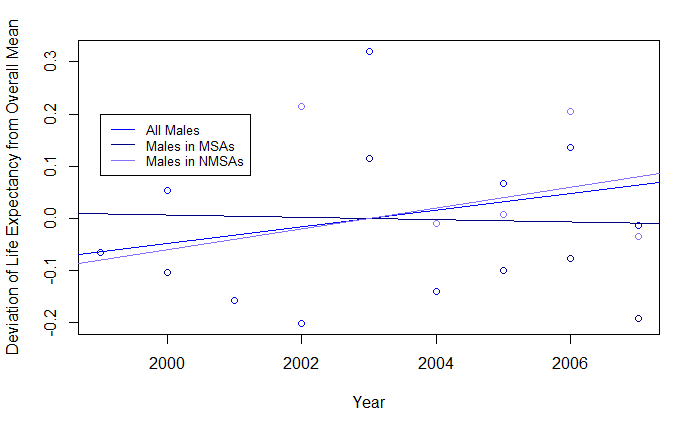

```r
legend(1999,0.2, legend = c("All Males","Males in MSAs","Males in NMSAs"), col = c("blue","navyblue","lightslateblue"),lty=1, cex=0.8)
```

```r
trendfemale <- fixef(plmwithinFemale,type="dmean")
#trend
trenddffemale <- data.frame("Year" = c(1999:2007),"Value"= trendfemale)
plot(trenddffemale, col = "grey", ylab = "Deviation of Life Expectancy from Overall Mean")
legend(1999,0.2, legend = c("All Females","Females in MSAs", "Females in NMSAs"), col = c("grey","grey0","grey39"),lty=1, cex=0.8)
```

```r
abline(lm(trenddffemale$Value~trenddffemale$Year), col="grey") # regression line (y~x)
#axis(1, at=1:9, labels=c(1999:2007))
summary(trendfemale)
```

```
      Estimate Std. Error t-value Pr(>|t|)
1999 -0.091978   0.233543 -0.3938   0.6937
2000  0.070137   0.233556  0.3003   0.7640
2001 -0.161306   0.231088 -0.6980   0.4852
2002 -0.188034   0.230033 -0.8174   0.4137
2003  0.309908   0.230093  1.3469   0.1780
2004 -0.171588   0.233266 -0.7356   0.4620
2005  0.071070   0.231971  0.3064   0.7593
2006  0.147810   0.229564  0.6439   0.5197
2007  0.013981   0.231278  0.0605   0.9518
```

```r
#MSA
trendfemaleMSA <- fixef(plmwithinMSAFemale,type="dmean")
trenddffemaleMSA <- data.frame("Year" = c(1999:2007),"Value"= trendfemaleMSA)
points(trenddffemaleMSA, col = "grey0")
```

```r
abline(lm(trenddffemaleMSA$Value~trenddffemaleMSA$Year), col="grey0") # regression line (y~x)
#axis(1, at=1:9, labels=c(1999:2007))
summary(trendfemaleMSA)
```

```
      Estimate Std. Error t-value Pr(>|t|)
1999 -0.059657   0.471036 -0.1267   0.8992
2000 -0.074420   0.475621 -0.1565   0.8757
2001  0.185114   0.474650  0.3900   0.6966
2002 -0.238471   0.478620 -0.4982   0.6183
2003  0.074750   0.472363  0.1582   0.8743
2004  0.122755   0.478645  0.2565   0.7976
2005  0.118691   0.476506  0.2491   0.8033
2006 -0.013327   0.469633 -0.0284   0.9774
2007 -0.115434   0.485139 -0.2379   0.8119
```

```r
#nonMSA
trendfemaleNMSA <- fixef(plmwithinnonMSAFemale,type="dmean")
trenddffemaleNMSA <- data.frame("Year" = c(1999:2007),"Value"= trendfemaleNMSA)
points(trenddffemaleNMSA, col = 'grey39')
```

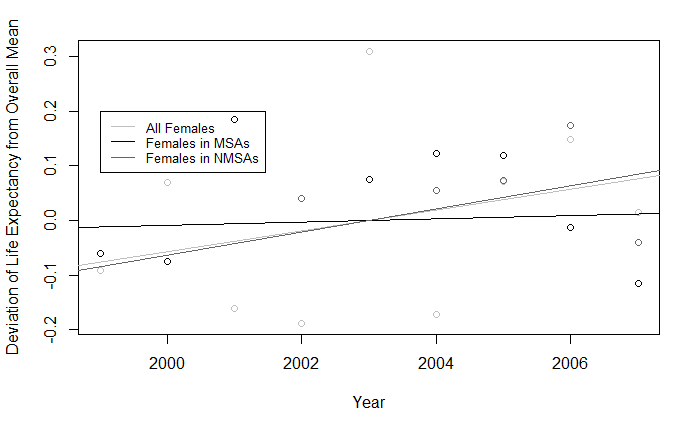

```r
abline(lm(trenddffemaleNMSA$Value~trenddffemaleNMSA$Year), col="grey39") # regression line (y~x)
axis(1, at=1:9, labels=c(1999:2007))
```

```r
summary(trendfemaleNMSA)
```

```
      Estimate Std. Error t-value Pr(>|t|)
1999 -0.221633   0.230167 -0.9629  0.33560
2000 -0.243912   0.230465 -1.0584  0.28991
2001  0.433930   0.232034  1.8701  0.06149 .
2002  0.040802   0.232541  0.1755  0.86072
2003 -0.271344   0.231967 -1.1698  0.24212
2004  0.055233   0.232794  0.2373  0.81246
2005  0.072918   0.233334  0.3125  0.75466
2006  0.173734   0.224780  0.7729  0.43959
2007 -0.039728   0.234381 -0.1695  0.86540
---
Signif. codes:  0 *** 0.001 ** 0.01 * 0.05 . 0.1   1
```

```r
#axis(1, at=1:9, labels=c(1999:2007))
```

The plot shows that for males, life expectancy is increasing in general and in nonMSAs, but decreasing in MSAs. For females, life expectancy is increasing for all categories, but the rate of increase in MSAs is very slow. However, the data used to construct the plot did not yield statistically significant results, so the information should not be seriously considered.

The mean life expectancy not accounting for the effect of time is extracted for males and females in both MSAs and non MSAs.

```r
#Extracting fixed effects with fixef
twoway <-  plm(MSAs$Male.life.expectancy..years ~ MSAs$MSA + MSAs$Diabetes.PrevalenceTotal.Males+MSAs$Smoking.Prevalence.Males.Daily.. + MSAs$Alcohol.Use.Any.. + MSAs$Obesity.Prevalence.Males.. + MSAs$Physical.Activity..Any..Prevalence.Males.., data = MSAs,model="within",effect="time")
MSAsFexef <- fixef(twoway,effect="time")
mean(MSAsFexef)
```

```
[1] 81.00965
```

```r
twoway <-  plm(nonMSAs$Male.life.expectancy..years ~ nonMSAs$MSA + nonMSAs$Diabetes.PrevalenceTotal.Males+nonMSAs$Smoking.Prevalence.Males.Daily.. + nonMSAs$Alcohol.Use.Any.. + nonMSAs$Obesity.Prevalence.Males.. + nonMSAs$Physical.Activity..Any..Prevalence.Males.., data = nonMSAs,model="within",effect="time")
nonMSAsFexef <- fixef(twoway,effect="time")
mean(nonMSAsFexef)
```

```
[1] 72.12279
```

```r
twoway <-  plm(MSAs$Female.life.expectancy..years ~ MSAs$MSA + MSAs$Diabetes.PrevalenceTotal.Females+MSAs$Smoking.Prevalence.Females.Daily.. + MSAs$Alcohol.Use.Any.. + MSAs$Obesity.Prevalence.Females.. + MSAs$Physical.Activity..Any..Prevalence.Females.., data = MSAs,model="within",effect="time")
MSAsFexef <- fixef(twoway,effect="time")
mean(MSAsFexef)
```

```
[1] 84.19794
```

```r
twoway <-  plm(nonMSAs$Female.life.expectancy..years ~ nonMSAs$MSA + nonMSAs$Diabetes.PrevalenceTotal.Females+nonMSAs$Smoking.Prevalence.Females.Daily.. + nonMSAs$Alcohol.Use.Any.. + nonMSAs$Obesity.Prevalence.Females.. + nonMSAs$Physical.Activity..Any..Prevalence.Females.., data = nonMSAs,model="within",effect="time")
nonMSAsFexef <- fixef(twoway,effect="time")
mean(nonMSAsFexef)
```

```
[1] 73.80071
```

The results show that, consistent with the other results from this analysis, both males and females have longer life expectancies in MSAs that in non MSAs.